# Experiment 1 - Analysis

Bodo Winter

7/3/2019

## Preliminaries:

Load packages:

```r
library(tidyverse)
library(brms)
```

Load in data:

```r
header <- readLines('../data/E1_forwardbackward.csv', n = 1)
E1 <- read_csv('../data/E1_forwardbackward.csv', skip = 2,
               col_names = FALSE)
colnames(E1) <- unlist(str_split(header, ','))
```

Rename relevant columns:

```r
E1 <- rename(E1,
             Control = MathQuestion,
             Age = age,
             Gender = gender,
             Handedness = handedness,
             NativeLanguage = language,
             Condition = `DO-BR-FL_10`,
             Comments = OpenEnded,
             Notice = GestureNotice,
             ViewN = VideoNTimes,
             ViewYes = VideoCompletion,
             IP = V6,
             StartTime = V8,
             EndTime = V9)
```

Get all_responses:

```r
# Initialize empty column for responses:

E1$Response <- NA

# The relevant columns all have '_resp':

these_cols <- str_detect(colnames(E1), '_resp')

# The relevant columns all have '_resp':

for (i in 1:nrow(E1)) {
  this <- unlist(E1[i, these_cols])
  names(this) <- c()
  if (!all(is.na(this))) {
    E1[i, ]$Response <- this[!is.na(this)]
  }
  }
```

Get rid of my test response:

```r
exclude_ids <- which(E1$Comments == 'bodo')
E1 <- E1[-exclude_ids, ]
```

Exclude those partials that did not respond and report loss. For proper reporting (since there will be several rounds of exclusion), it makes sense to create a tibble:

```r
# Original tibble:

excl_tib <- tibble(N = nrow(E1), Type = 'Original')

# Those that didn't respond:

E1 <- filter(E1, !is.na(Response))

# New tibble to keep track of exclusions:

new_tib <- tibble(N = nrow(E1), Type = 'after partials')
excl_tib <- bind_rows(excl_tib, new_tib)
```

Exclude those that are duplicated responses (from the same IP):

```r
# Those that didn't respond:

these_IPs <- filter(E1, duplicated(IP)) %>% pull(IP)
E1 <- filter(E1, !(IP %in% these_IPs))

# New tibble to keep track of exclusions:

new_tib <- tibble(N = nrow(E1), Type = 'after duplicates')
excl_tib <- bind_rows(excl_tib, new_tib)
```

Select subset of dataframe with relevant columns:

```r
E1 <- select(E1,
             ViewYes:NativeLanguage, Notice, Condition, IP, Response, StartTime, EndTime)
```

Get rid of non-native speakers:

```r
# Vector of things to exclude:

excludes <- c('French', '', 'no', 'Vietnamese')

# Exclude:

E1 <- filter(E1, !(NativeLanguage %in% excludes))

# New tibble to keep track of exclusions:

new_tib <- tibble(N = nrow(E1), Type = 'after non-natives')
excl_tib <- bind_rows(excl_tib, new_tib)
```

Get rid of people who couldn’t view the videos:

```r
# Exclude:

E1 <- filter(E1, ViewYes == 'Yes')

# Get rid of those that report to have had a viewing problem:

excludes <- c("The video didn't load correctly at first, it kept starting and stopping.",
              "There was a lag in the video that messed up the sync of audio and video that kind of threw me off.",
              "Mouth did not match the voice in parts.",
              "The voice of the person is somehow too low, and my computer's speaker cannot play it clearly.")

# Exclude these:

exclude_ids <- which(E1$Comments %in% excludes)
E1 <- E1[-exclude_ids, ]

excludes <- c("Twice because my sound was not playing properly. I could not hear him at all on the first time.",
              "I viewed it three times, because I had forgotten my headphones were plugged in.",
              "2 times because i could not hear it the first time",
              "I did not see the person in the video move.  All I heard was the voice")
exclude_ids <- which(E1$ViewN %in% excludes)
E1 <- E1[-exclude_ids, ]

# New tibble to keep track of exclusions:

new_tib <- tibble(N = nrow(E1), Type = 'after viewing problems')
excl_tib <- bind_rows(excl_tib, new_tib)
```

Process viewing times:

```r
# Get rid of that NA response for view N:

E1 <- filter(E1, !is.na(ViewN))
E1 <- filter(E1, ViewN != '`')

# Make it into lowercase for easier processing:

E1 <- mutate(E1, ViewN = str_to_lower(ViewN))

# Create a table that matches responses to counts:

ViewN <- c('1', 'once', 'one',
           '2', 'two', 'twice',
           'three', '3')
ViewCount = c(1, 1, 1,
              2, 2, 2,
              3, 3)
key <- tibble(ViewN, ViewCount)

# Merge these counts into the data frame:

E1 <- left_join(E1, key)
```

Assess whether the viewing times depend on condition:

```r
E1 %>% group_by(Condition) %>%
  summarize(sum = sum(ViewCount))
```

```
## # A tibble: 4 x 2
##   Condition    sum
##   <chr>      <dbl>
## 1 E1_A_FG_BL    64
## 2 E1_B_BG_BL    71
## 3 E1_C_FG_FL    65
## 4 E1_D_BG_FL    70
```

Not massive differences…

Create the Monday/Friday column:

```r
E1 <- mutate(E1,
             Response = str_to_lower(Response))

E1$RespClean <- NA
E1[str_detect(E1$Response, 'monday'), ]$RespClean <- 'monday'
E1[str_detect(E1$Response, 'friday'), ]$RespClean <- 'friday'
E1[E1$Response == "monday or tuesday", ]$RespClean <- NA

# Exclude those that responded neither monday nor friday:

E1 <- filter(E1, !is.na(RespClean))

# New tibble to keep track of exclusions:

new_tib <- tibble(N = nrow(E1), Type = 'after wrong-day responders')
excl_tib <- bind_rows(excl_tib, new_tib)
```

Code for multiple views versus single views:

```r
# If you wanted to take only those that had only one view:

# E1 <- filter(E1, ViewCount == 1)

# Multiple viewers as a separate variable:

E1 <- mutate(E1,
             MultipleView = ifelse(ViewCount == 1, 'single', 'multiple'))

# New tibble to keep track of exclusions (only necessary if excluded):

# new_tib <- tibble(N = nrow(E1), Type = 'after multiple viewers')
# excl_tib <- bind_rows(excl_tib, new_tib)
```

Code condition column:

```r
E1 <- separate(E1,
               Condition,
               into = c('experiment', 'Cond', 'Gesture', 'Language')) %>%
  select(-experiment, -Cond)
```

Get rid of the original response column:

```r
E1 <- mutate(E1,
             Response = RespClean) %>%
  select(-RespClean)
```

For plotting make it so that the Response factor is “monday”, then “friday” (easier: from left to right).

```r
E1 <- mutate(E1,
             Response = str_to_title(Response),
             Response = factor(Response, levels = c('Monday', 'Friday')))
```

Change the labels in the Gesture and Language columns to make them better for plotting:

```r
E1 <- mutate(E1,
             Gesture = ifelse(Gesture == 'BG', 'backward', 'forward'),
             Language = ifelse(Language == 'BL', 'backward language', 'forward language'))
```

Order of factor levels so that it works better for the models below:

```r
E1 <- mutate(E1,
             Gesture = factor(Gesture, levels = c('forward', 'backward')),
             Language = factor(Language, levels = c('forward language', 'backward language')))
```

Look at those folks that notice strange accent etc.

```r
# Those who commented on the mismatch or weird gestures:

weirds <- readLines('../data/E1_comments_weird.txt')

# Those who commented on the strangeness of the person or accent:

person <- readLines('../data/E1_comments_person.txt')

# Add this info to the tibble:

E1$Weird <- 'nothing'
ids <- which(E1$Comments %in% weirds)
E1[ids, ]$Weird <- 'weird'

E1$Person <- 'nothing'
ids <- which(E1$Comments %in% person)
E1[ids, ]$Person <- 'person'
```

Overview of exclusions:

```r
excl_tib$Exclusions <- c(0, abs(diff(excl_tib$N)))
excl_tib$Prop <- NA
for (i in 2:nrow(excl_tib)) {
  excl_tib[i, ]$Prop <- excl_tib[i, ]$N / excl_tib[i - 1, ]$N
}
excl_tib <- mutate(excl_tib, Prop = 1 - Prop)
excl_tib
```

```
## # A tibble: 6 x 4
##       N Type                       Exclusions     Prop
##   <int> <chr>                           <dbl>    <dbl>
## 1   278 Original                            0 NA
## 2   249 after partials                     29  0.104
## 3   239 after duplicates                   10  0.0402
## 4   237 after non-natives                   2  0.00837
## 5   227 after viewing problems             10  0.0422
## 6   191 after wrong-day responders         36  0.159
```

And the overall exclusion:

```r
excl_tib[1, ]$N - excl_tib[nrow(excl_tib), ]$N
```

```
## [1] 87
```

```r
(excl_tib[1, ]$N - excl_tib[nrow(excl_tib), ]$N) / excl_tib[1, ]$N
```

```
## [1] 0.3129496
```

What’s reported in the paper is the following, the number of participants that are actually participants of the study (N = 239) compared to the 191 participants that are included in the analysis.

```r
orig <- filter(excl_tib, Type == 'after duplicates')$N
final <- filter(excl_tib, Type == 'after wrong-day responders')$N
orig - final
```

```
## [1] 48
```

```r
1 - (final / orig)
```

```
## [1] 0.2008368
```

Check the comprehension question:

```r
all(E1$Control == 13)
```

```
## [1] TRUE
```

What does the total sample consist of in terms of demographics?

```r
table(E1$Gender)
```

```
##
## female   male
##     65    126
```

```r
mean(as.numeric(E1$Age), na.rm = TRUE)
```

```
## [1] 34.29843
```

```r
range(as.numeric(E1$Age), na.rm = TRUE)
```

```
## [1] 19 67
```

## Descriptive stats and visualizations:

First, how many were aware of the gestures?

```r
E1 %>% count(Notice, sort = TRUE)
```

```
## # A tibble: 5 x 2
##   Notice                 n
##   <chr>              <int>
## 1 Definitely yes       176
## 2 Probably yes          11
## 3 Probably not           2
## 4 Definitely not         1
## 5 Might or might not     1
```

Lots of them.

Tabulations of the main result:

```r
E1 %>% count(Response)
```

```
## # A tibble: 2 x 2
##   Response     n
##   <fct>    <int>
## 1 Monday     136
## 2 Friday      55
```

Overall many more Monday responses.

```r
E1 %>% count(Language, Response)
```

```
## # A tibble: 4 x 3
##   Language          Response     n
##   <fct>             <fct>    <int>
## 1 forward language  Monday      53
## 2 forward language  Friday      41
## 3 backward language Monday      83
## 4 backward language Friday      14
```

More Monday responses when the language is backward.

```r
E1 %>% count(Language, Gesture, Response)
```

```
## # A tibble: 8 x 4
##   Language          Gesture  Response     n
##   <fct>             <fct>    <fct>    <int>
## 1 forward language  forward  Monday      24
## 2 forward language  forward  Friday      23
## 3 forward language  backward Monday      29
## 4 forward language  backward Friday      18
## 5 backward language forward  Monday      38
## 6 backward language forward  Friday       6
## 7 backward language backward Monday      45
## 8 backward language backward Friday       8
```

## Publication ready stacked bar plot:

Stacked bar plot with percentages:

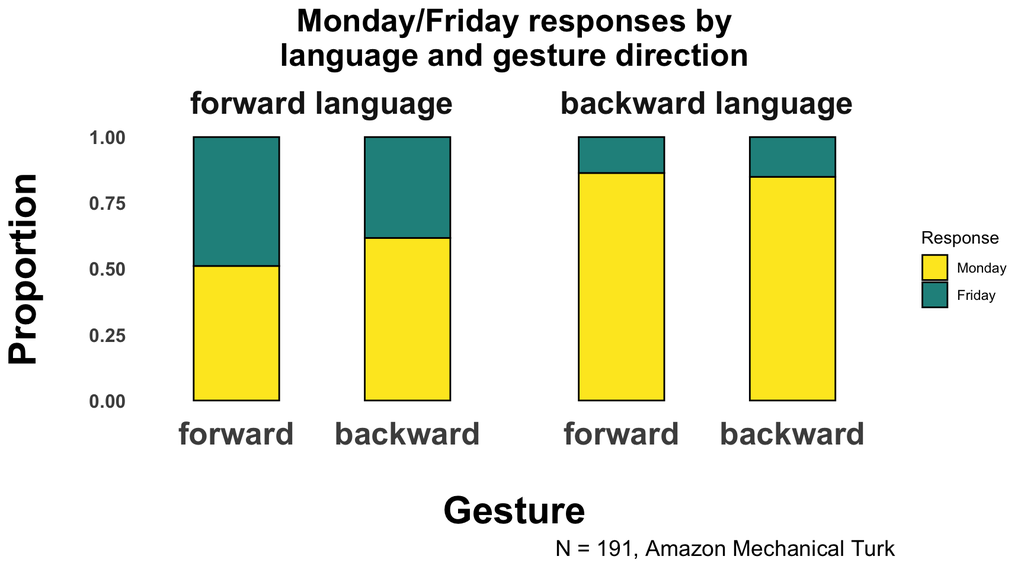

```r
E1 %>%
  count(Language, Gesture, Response) %>%
  spread(Response, n) %>%
  mutate(Sum = Monday + Friday,
         Monday = Monday / Sum,
         Friday = Friday / Sum) %>%
  select(-Sum) %>%
  gather(key = 'Response', value = 'n',
         -(Language:Gesture)) %>%
  mutate(Response = factor(Response,
                           levels = c('Monday', 'Friday'))) %>%
  rename(Proportion = n) %>%
  ggplot(aes(x = Gesture, y = Proportion, fill = Response)) +
  geom_bar(stat = 'identity', col = 'black',
           position = position_stack(reverse = TRUE),
           width = 0.5) +
  scale_fill_manual(values = c('#FDE725FF', '#21908CFF')) +
  theme_minimal() +
  theme(legend.position = 'right') +
  facet_wrap(~Language) +
  labs(title = 'Monday/Friday responses by\nlanguage and gesture direction',
       caption = str_c('N = ', nrow(E1), ', Amazon Mechanical Turk')) +
  ylab('Proportion\n') +
  xlab('\nGesture') +
  theme(plot.title = element_text(face = 'bold', size = 20, hjust = 0.5),
        axis.title = element_text(face = 'bold', size = 24),
        axis.text.x = element_text(face = 'bold', size = 20),
        axis.text.y = element_text(face = 'bold', size = 12),
        strip.text.x = element_text(face = 'bold', size = 20),
        plot.caption = element_text(size = 14),
        panel.grid.minor = element_blank(),
        panel.grid.major = element_blank())
```

```r
ggsave('../figures/experiment1.png', width = 9, height = 6)
```

## Exploring “weird” self-reports:

Check to what extent these things are moderated by the weirdness factor:

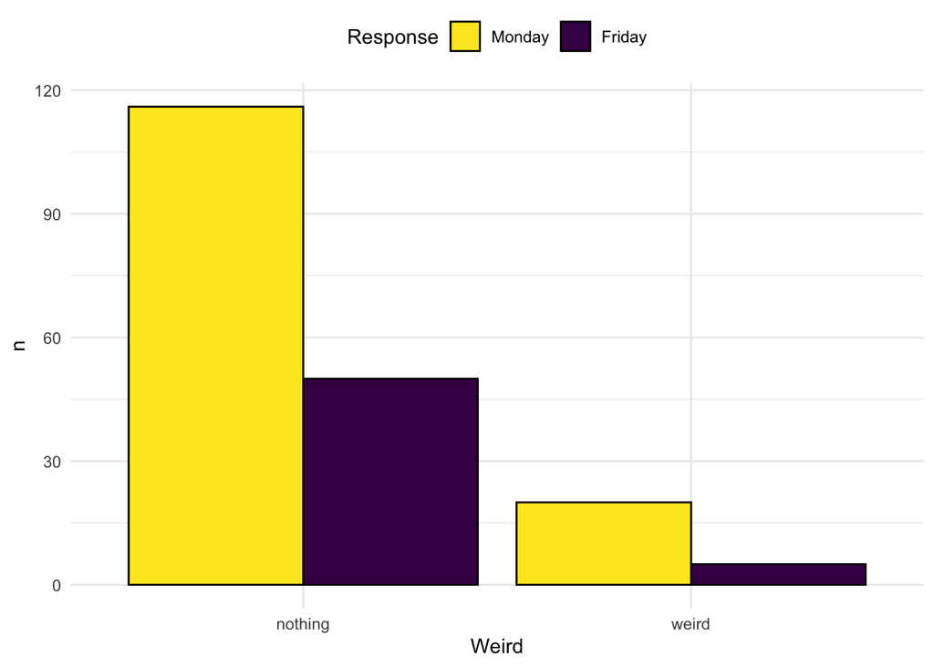

```r
E1 %>%
  count(Weird, Response) %>%
  ggplot(aes(x = Weird, y = n, fill = Response)) +
  geom_bar(stat = 'identity', col = 'black',
           position = 'dodge') +
  scale_fill_viridis_d(option = 'D', direction = -1) +
  theme_minimal() +
  theme(legend.position = 'top')
```

Nothing much … perhaps slightly more Monday respnses for the ones that think it’s weird.

Which condition did people think was the weirdest?

```r
E1 %>% count(Language, Gesture, Weird) %>%
  spread(Weird, n) %>%
  mutate(Weirdness = weird / (nothing + weird))
```

```
## # A tibble: 4 x 5
##   Language          Gesture  nothing weird Weirdness
##   <fct>             <fct>      <int> <int>     <dbl>
## 1 forward language  forward       43     4    0.0851
## 2 forward language  backward      35    12    0.255
## 3 backward language forward       38     6    0.136
## 4 backward language backward      50     3    0.0566
```

What about those that thought something other about the person?

```r
E1 %>% count(Language, Gesture, Person, Response) %>%
  spread(Response, n, fill = 0) %>%
  mutate(Monday = Monday / (Monday + Friday))
```

```
## # A tibble: 8 x 5
##   Language          Gesture  Person  Monday Friday
##   <fct>             <fct>    <chr>    <dbl>  <dbl>
## 1 forward language  forward  nothing  0.477     23
## 2 forward language  forward  person   1          0
## 3 forward language  backward nothing  0.581     18
## 4 forward language  backward person   1          0
## 5 backward language forward  nothing  0.846      6
## 6 backward language forward  person   1          0
## 7 backward language backward nothing  0.843      8
## 8 backward language backward person   1          0
```

## Model this with logistic regression:

Sum-code the categorical predictors:

```r
contrasts(E1$Language) <- contr.sum(2) / 2
contrasts(E1$Gesture) <- contr.sum(2) / 2
```

Set the parameters for a Bayesian analysis:

```r
# For parallel processing:

options(mc.cores=parallel::detectCores())

# For handling the MCMC sampling:

my_controls <- list(adapt_delta = 0.99,
                    max_treedepth = 13)
```

Set regularizing priors on betas:

```r
my_priors <- c(prior(normal(0, 1), class = b))
```

Specify and run the model:

```r
E1_mdl <- brm(Response ~ Language * Gesture,
              data = E1,
              family = bernoulli,
              init = 0,
              chains = 8,
              warmup = 2000,
              iter = 8000,
              prior = my_priors,
              control = my_controls)
save(E1_mdl, file = '../models/E1_mdl.RData')
```

Summarize the model:

```r
summary(E1_mdl)
```

```
##  Family: bernoulli
##   Links: mu = logit
## Formula: Response ~ Language * Gesture
##    Data: E1 (Number of observations: 191)
## Samples: 8 chains, each with iter = 8000; warmup = 2000; thin = 1;
##          total post-warmup samples = 48000
##
## Population-Level Effects:
##                    Estimate Est.Error l-95% CI u-95% CI Eff.Sample Rhat
## Intercept             -1.02      0.18    -1.37    -0.68      40735 1.00
## Language1              1.39      0.33     0.75     2.05      39167 1.00
## Gesture1               0.18      0.33    -0.46     0.83      41079 1.00
## Language1:Gesture1     0.37      0.57    -0.75     1.49      40339 1.00
##
## Samples were drawn using sampling(NUTS). For each parameter, Eff.Sample
## is a crude measure of effective sample size, and Rhat is the potential
## scale reduction factor on split chains (at convergence, Rhat = 1).
```

Plot marginal effects:

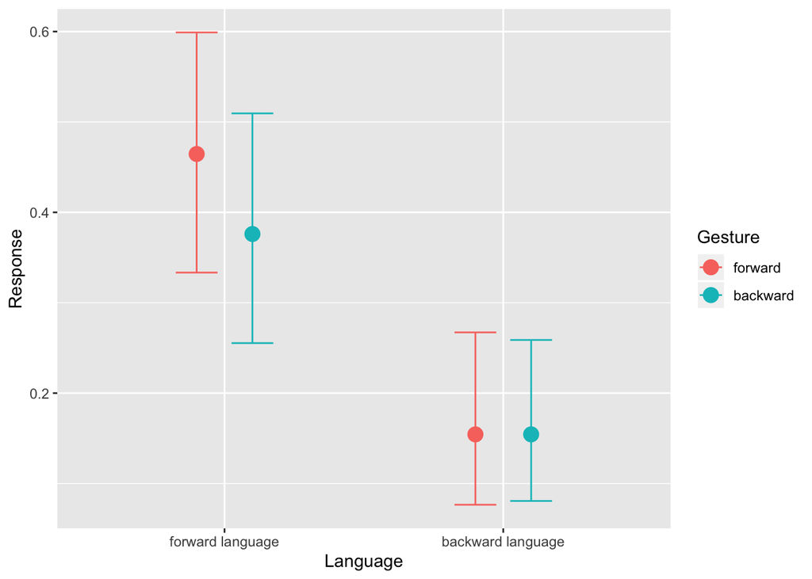

```r
conditions <- make_conditions(E1_mdl, 'Language')
marginal_effects(E1_mdl, effects = 'Language:Gesture')
```

Check how many of the posteriors were in the predicted direction:

```r
# To aid interpretation:

levels(E1$Response)
```

```
## [1] "Monday" "Friday"
```

```r
contrasts(E1$Language)
```

```
##                   [,1]
## forward language   0.5
## backward language -0.5
```

```r
# Extract posterior samples:

mypost <- posterior_samples(E1_mdl)

# Posterior probability of the language effect being above 0:

sum(mypost$b_Language1 > 0) / nrow(mypost)
```

```
## [1] 1
```

```r
# Same for the language effect:

sum(mypost$b_Gesture1 > 0) / nrow(mypost)
```

```
## [1] 0.7098542
```

Save the results outside for subsequent meta-analysis:

```r
write_csv(E1, '../data/cleaned_data/E1_cleaned.csv')
```

This completes this analysis.